# Setup: Integration Module

Stephanie Spielman for the Data Lab

2022-12-06

## Download Data

This data comes from `ScPCA` project `SCPCP000005` (https://scpca.alexslemonade.org/projects/SCPCP000005) which also has cell type information. We use four different samples from this project that have the same technology (single-nucleus, 10Xv3), and these unprocessed samples are expected to be saved in the directory specified in the `input_sce_path` parameter.

- `SCPCS000252` (`SCPCL000478_filtered.rds`)
- `SCPCS000253` (`SCPCL000479_filtered.rds`)
- `SCPCS000254` (`SCPCL000480_filtered.rds`)
- `SCPCS000255` (`SCPCL000481_filtered.rds`)

Similarly, `celltypes.tsv` is expected to be in the directory specified in the `input_sce_path` parameter.

## Functional programming!

We’ll have to take the same steps several times across several SCEs, why not use some functions to help us! Even better, why not use some functional programming?! Come along!

## Load Data

First we’ll read in the SCE objects.

```r
# Check input path
if (!(dir.exists(params$input_sce_path))) {
  stop("Bad `input_sce_path`; check parameter.")
}

# We'll export processed SCEs here:
if (!(dir.exists(params$output_sce_path))) {
  dir.create(output_dir, recursive = TRUE)
}

# Make this a list of paths:
sce_paths <- list.files(params$input_sce_path, pattern = "_filtered.rds", full.names = TRUE)
sce_names <- stringr::str_extract_all(sce_paths, "SCPCL\\d+") %>% unlist()
sce_paths <- as.list(sce_paths)
names(sce_paths) <- sce_names

# We can read all these files in at once using purrr::map over
#  the sce_paths list
sce_list <- purrr::map(
  sce_paths,
  readr::read_rds
)

# We now have a named list of SCE objects
sce_list
```

```
$SCPCL000478
class: SingleCellExperiment
dim: 60319 6567
metadata(14): salmon_version reference_index ... filtering_method miQC_model
assays(1): counts
rownames(60319): ENSG00000000003 ENSG00000000005 ... ENSG00000288724 ENSG00000288725
rowData names(3): gene_symbol mean detected
colnames(6567): CTATAGGCAACACGAG TTGATGGCATCACGGC ... CGTTGGGAGCGTCGAA GTGGAAGAGCGACCCT
colData names(8): sum detected ... prob_compromised miQC_pass
reducedDimNames(0):
mainExpName: NULL
altExpNames(0):

$SCPCL000479
class: SingleCellExperiment
dim: 60319 3781
metadata(14): salmon_version reference_index ... filtering_method miQC_model
assays(1): counts
rownames(60319): ENSG00000000003 ENSG00000000005 ... ENSG00000288724 ENSG00000288725
rowData names(3): gene_symbol mean detected
colnames(3781): GGGACCTCAAGCGGAT CACAGATAGTGAGTGC ... GAATAGATCGATGCTA CCTACGTCAACACGAG
colData names(8): sum detected ... prob_compromised miQC_pass
reducedDimNames(0):
mainExpName: NULL
altExpNames(0):

$SCPCL000480
class: SingleCellExperiment
dim: 60319 7601
metadata(14): salmon_version reference_index ... filtering_method miQC_model
assays(1): counts
rownames(60319): ENSG00000000003 ENSG00000000005 ... ENSG00000288724 ENSG00000288725
rowData names(3): gene_symbol mean detected
colnames(7601): TAGGGTTAGCAAGCCA AACTTCTTCCCTCAAC ... CATTCCGTCTACGGGC TTTCATGGTATGCAAA
colData names(8): sum detected ... prob_compromised miQC_pass
reducedDimNames(0):
mainExpName: NULL
altExpNames(0):

$SCPCL000481
class: SingleCellExperiment
dim: 60319 9483
metadata(14): salmon_version reference_index ... filtering_method miQC_model
assays(1): counts
rownames(60319): ENSG00000000003 ENSG00000000005 ... ENSG00000288724 ENSG00000288725
rowData names(3): gene_symbol mean detected
colnames(9483): TCATGAGAGGCCCACT GGGTATTTCGTTGTGA ... AGGGCTCTCATATGGC TACCGGGAGCTTTCTT
colData names(8): sum detected ... prob_compromised miQC_pass
reducedDimNames(0):
mainExpName: NULL
altExpNames(0):
```

Next, we’ll read in a TSV file containing previously determined cell types for these cells. These cell types were originally assigned in [this publication](https://doi.org/10.1016/j.devcel.2022.04.003).

```r
celltypes_df <- readr::read_tsv(params$celltypes_file)
celltypes_df
```

| library | barcode | celltype |
| --- | --- | --- |
| SCPCL000478 | CCTTTGGCACTACCCT | NA |
| SCPCL000478 | GCAACCGGTCTTAGTG | NA |
| SCPCL000478 | TCACTATCAAATCCCA | Vascular Endothelium |
| SCPCL000478 | TATATCCCACTCTCGT | Vascular Endothelium |
| SCPCL000478 | GCACTAACATTACGGT | NA |
| SCPCL000478 | ACCCAAAAGTTGGGAC | NA |
| SCPCL000478 | CTACGGGCAACTTCTT | Fibroblast |
| SCPCL000478 | ATGGATCGTTACCTGA | Fibroblast |
| SCPCL000478 | GACACGCCAGCGGTCT | NA |
| SCPCL000478 | CTACCCAAGCAATAAC | Vascular Endothelium |

[output cut: 990 more lines]

```r
# What are the subtypes in this data?
unique(celltypes_df$celltype)
```

```
 [1] NA                     "Vascular Endothelium" "Fibroblast"           "Tumor"                "Monocyte"
 [6] "Lymphocyte"           "Tumor_Myoblast-A"     "Tumor_Myoblast-B"     "Tumor_Mesoderm"       "Tumor_Myoblast-C"
[11] "Tumor_Myoblast-D"     "Tumor_Myocyte-A"      "Muscle"               "Tumor_Myocyte-B"
```

We’ll also create a second cell type column, `celltype_broad`, which groups together all the `Tumor_Myoblast-` and `Tumor_Myocyte-` categories into one each, and rename the current column to `celltype_fine` to differentiate.

```r
celltypes_df <- celltypes_df %>%
  dplyr::mutate(celltype_broad = stringr::str_remove(celltype, "-[ABCD]$")) %>%
  # We'll also rename `celltype` to `celltype_fine`
  dplyr::rename(celltype_fine = celltype)
```

## Filter and normalize the SCEs

Before filtering, we’ll explore the distributions of gene counts across SCEs to find a reasonable threshold.

```r
# This had already been filtered to >= 500, so nothing more to do here
purrr::map(
  sce_list,
  ~ summary(colData(.)$sum)
)
```

```
$SCPCL000478
   Min. 1st Qu.  Median    Mean 3rd Qu.    Max.
    501    1073    2011    3441    3911   90332

$SCPCL000479
   Min. 1st Qu.  Median    Mean 3rd Qu.    Max.
    501    1415    2342    3778    4578   43417

$SCPCL000480
   Min. 1st Qu.  Median    Mean 3rd Qu.    Max.
    503    2052    2702    3228    3639   72936

$SCPCL000481
   Min. 1st Qu.  Median    Mean 3rd Qu.    Max.
    501    3780    5126    5699    7036   61355
```

```r
# A threshold of 500 seems ok here:
purrr::map(
  sce_list,
  ~summary(colData(.)$detected)
)
```

```
$SCPCL000478
   Min. 1st Qu.  Median    Mean 3rd Qu.    Max.
     34     669    1161    1467    1880   11482

$SCPCL000479
   Min. 1st Qu.  Median    Mean 3rd Qu.    Max.
     56     607     945    1436    1965    6222

$SCPCL000480
   Min. 1st Qu.  Median    Mean 3rd Qu.    Max.
    185    1281    1596    1726    1995   10788

$SCPCL000481
   Min. 1st Qu.  Median    Mean 3rd Qu.    Max.
    141    2125    2620    2666    3220   10044
```

Now let’s filter and normalize:

```r
filter_and_normalize_sce <- function(sce) {

  # Filter based on miQC:
  filtered_sce <- sce[, which(sce$miQC_pass)]

  # Filter to detected >= 500
  filtered_sce <- filtered_sce[, filtered_sce$detected >= 500]

  # Normalize:
  qclust <- scran::quickCluster(filtered_sce)
  filtered_sce <- scran::computeSumFactors(filtered_sce, clusters = qclust)
  norm_sce <- scater::logNormCounts(filtered_sce)

  # Return the normalized SCE
  return(norm_sce)
}

sce_list <- purrr::map(
  sce_list,
  filter_and_normalize_sce
)
```

## Dimension reduction

Now, let’s add PCA and UMAP for each individual library:

```r
calc_dimred <- function(sce) {

  # calculate high-variance genes to use for dimension reduction
  gene_variance <- scran::modelGeneVar(sce)
  hvg_list <- scran::getTopHVGs(gene_variance,
                                n = 2000)

  # Add PCA and UMAP into the SCE
  sce <- sce %>%
    scater::runPCA(subset_row = hvg_list) %>%
    scater::runUMAP(dimred = "PCA")

  # Return the SCE
  return(sce)
}

sce_list <- purrr::map(
  sce_list,
  calc_dimred
)
```

## Add in cell type information

When performing dataset integration, it can be helpful to refer back to cell types to assess how well integration performed. In many real-world circumstances, be aware that cell types are usually not *a priori* known, and in either case this information is *not* directly used during integration itself. Therefore, for the purposes of these exercises, we’ll add the cell types into the SCEs for future use.

```r
add_celltype_info <- function(sce, sce_name, celltypes_df) {

  # Add a matching barcode variable into the colData
  colData(sce)$barcode <- colnames(sce)

  # filter to cells in this SCE
  celltypes_df <- celltypes_df %>%
    dplyr::filter(library == sce_name) %>%
    dplyr::select(-library)

  # join colDdata to celltype
  celltype_coldata <-  colData(sce) %>%
    as.data.frame() %>%
    # Use a left_join since there may be more cells in the SCE than there are in
    #  the celltypes
    dplyr::left_join(celltypes_df, by = "barcode" ) %>%
    #convert back to a DataFrame with row names
    S4Vectors::DataFrame(row.names = .$barcode)

  # check that the names of the cells are still consistent
  if (all(rownames(celltype_coldata) == colnames(sce))){
    colData(sce) <- celltype_coldata
  } else {
    stop("Error joining celltype_df to colData")
  }

  # Return the updated SCE
  return(sce)
}


# Update the SCEs to include new `celltype` column
# Incidentally a `barcode` column also gets added
sce_list <- purrr::imap(
  sce_list,
  add_celltype_info,
  celltypes_df = celltypes_df
)
```

At this point, SCE objects are prepared for the workshop so we’ll export them into RDS files.

```r
purrr::iwalk(
  sce_list,
  ~ readr::write_rds(
      .x,
      file.path(params$output_sce_path, paste0(.y, ".rds"))
    )
)
```

## Combine the SCEs

We now need to combine these SCEs into 1 object, which requires some bookkeeping. Specifically, we need to ensure:

- Genes/features (aka, the `rowData` slot names) must match
- The `colData` column names must match
- That we can identify the original library each cell came from
- Other useful information can still be found

```r
# What are the genes in common? Hold onto this vector!
# For these data they already had the same genes, but no guarantees of that
#   with data in the wild
shared_genes <- sce_list %>%
  # get rownames for each entry in sce_list
  purrr::map(rownames) %>%
  # find their intersection
  purrr::reduce(intersect)

# What are the colData names?
purrr::map(sce_list,
           ~names(colData(.)))
```

```
$SCPCL000478
 [1] "sum"                   "detected"              "subsets_mito_sum"      "subsets_mito_detected"
 [5] "subsets_mito_percent"  "total"                 "prob_compromised"      "miQC_pass"
 [9] "sizeFactor"            "barcode"               "celltype_fine"         "celltype_broad"

$SCPCL000479
 [1] "sum"                   "detected"              "subsets_mito_sum"      "subsets_mito_detected"
 [5] "subsets_mito_percent"  "total"                 "prob_compromised"      "miQC_pass"
 [9] "sizeFactor"            "barcode"               "celltype_fine"         "celltype_broad"

$SCPCL000480
 [1] "sum"                   "detected"              "subsets_mito_sum"      "subsets_mito_detected"
 [5] "subsets_mito_percent"  "total"                 "prob_compromised"      "miQC_pass"
 [9] "sizeFactor"            "barcode"               "celltype_fine"         "celltype_broad"

$SCPCL000481
 [1] "sum"                   "detected"              "subsets_mito_sum"      "subsets_mito_detected"
 [5] "subsets_mito_percent"  "total"                 "prob_compromised"      "miQC_pass"
 [9] "sizeFactor"            "barcode"               "celltype_fine"         "celltype_broad"
```

```r
# Some purrr magic can quickly show us any differences
purrr::map(sce_list,
           ~names(colData(.))) %>%
  purrr::reduce(setdiff)
```

```
character(0)
```

```r
# Let's have a peek at the rowData:
# `mean` and `detected` are SCE-specific, but `gene_symbol` is not! Bookkeeping!
purrr::map(sce_list,
           ~names(rowData(.)))
```

```
$SCPCL000478
[1] "gene_symbol" "mean"        "detected"

$SCPCL000479
[1] "gene_symbol" "mean"        "detected"

$SCPCL000480
[1] "gene_symbol" "mean"        "detected"

$SCPCL000481
[1] "gene_symbol" "mean"        "detected"
```

We want to format each SCE to meet our criteria:

```r
format_sce_list <- function(sce, sce_name, shared_genes) {

  # Reduce to shared genes
  sce <- sce[shared_genes,]

  # Update the colData row names so we can know where cells came from back
  # Alternatively we can just get rid of a lot of this?
  # glue is great!
  rownames(colData(sce)) <- glue::glue("{sce_name}-{rownames(colData(sce))}")

  # Update the rowData names, except `gene_symbol`
  names(rowData(sce)) <- ifelse(names(rowData(sce)) == "gene_symbol",
                                "gene_symbol",
                                glue::glue("{sce_name}-{rownames(rowData(sce))}")

  )
  # Add in sample-level information as stand-alone column
  colData(sce)$sample <- sce_name

  # Return
  return(sce)
}


# Prepare the sce_list for combining
sce_list <- purrr::imap(sce_list,
                        format_sce_list,
                        shared_genes = shared_genes)

# Combine!
combined_sce <- do.call(cbind, sce_list)
combined_sce
```

```
class: SingleCellExperiment
dim: 60319 14595
metadata(56): salmon_version reference_index ... filtering_method miQC_model
assays(2): counts logcounts
rownames(60319): ENSG00000000003 ENSG00000000005 ... ENSG00000288724 ENSG00000288725
rowData names(9): gene_symbol SCPCL000478-ENSG00000000005 ... SCPCL000481-ENSG00000000005
  SCPCL000481-ENSG00000000419
colnames(14595): SCPCL000478-CCTTTGGCACTACCCT SCPCL000478-GCAACCGGTCTTAGTG ...
  SCPCL000481-AAAGAACCACTTCAAG SCPCL000481-CAGCAGCTCGTGCATA
colData names(13): sum detected ... celltype_broad sample
reducedDimNames(2): PCA UMAP
mainExpName: NULL
altExpNames(0):
```

You’ll see that there are `PCA` and `UMAP` dimension reductions in this combined SCE. These represent the original reductions that were performed on *each individual library*. We can also calculate PCA and UMAP for the combined whole, which we will save with different names `combined_PCA` and `combined_UMAP` to distinguish. We can compare these UMAP embeddings to those calculated after performing integration.

```r
# calculate high-variance genes to use for dimension reduction
gene_variance <- scran::modelGeneVar(combined_sce,
                                     # For combined SCEs, specify the group column groups:
                                     block = combined_sce$sample)
hvg_list <- scran::getTopHVGs(gene_variance,
                              n = 2000)

# Add PCA and UMAP into the SCE
combined_sce <- scater::runPCA(combined_sce,
                               subset_row = hvg_list,
                               # Make sure not to overwrite the existing PCA!
                               name = "combined_PCA") %>%
  # again, make sure to use the right names
  scater::runUMAP(dimred = "combined_PCA",
                  name = "combined_UMAP")

combined_sce
```

```
class: SingleCellExperiment
dim: 60319 14595
metadata(56): salmon_version reference_index ... filtering_method miQC_model
assays(2): counts logcounts
rownames(60319): ENSG00000000003 ENSG00000000005 ... ENSG00000288724 ENSG00000288725
rowData names(9): gene_symbol SCPCL000478-ENSG00000000005 ... SCPCL000481-ENSG00000000005
  SCPCL000481-ENSG00000000419
colnames(14595): SCPCL000478-CCTTTGGCACTACCCT SCPCL000478-GCAACCGGTCTTAGTG ...
  SCPCL000481-AAAGAACCACTTCAAG SCPCL000481-CAGCAGCTCGTGCATA
colData names(13): sum detected ... celltype_broad sample
reducedDimNames(4): PCA UMAP combined_PCA combined_UMAP
mainExpName: NULL
altExpNames(0):
```

## Pre-integration visualization

To get a sense of our data *before* integrating, let’s look at UMAPs for each individual library and the combined SCE.

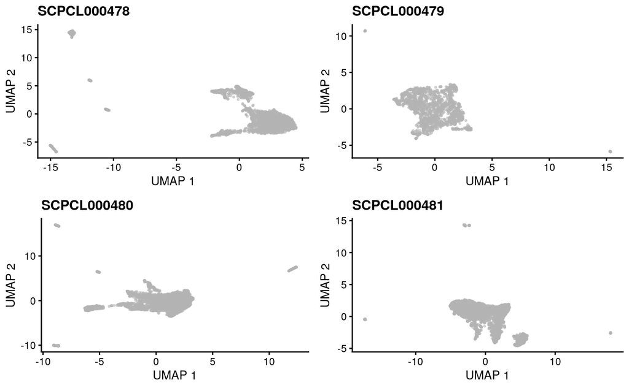

```r
plot_library_umap <- function(sce, sce_name) {
  scater::plotReducedDim(sce,
                         dimred = "UMAP",
                         point_size = 0.5,
                         point_alpha = 0.5) +
    ggplot2::ggtitle(sce_name)
}

umap_list <- purrr::imap(
  sce_list,
  plot_library_umap
)

cowplot::plot_grid(plotlist = umap_list, nrow = 2)
```

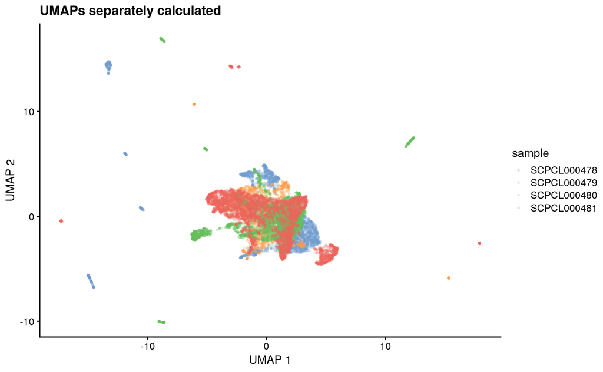

```r
# In the same coordinate space (each was scaled separately):
scater::plotReducedDim(combined_sce,
                       dimred = "UMAP",
                       colour_by = "sample",
                       # Some styling to help us see the points:
                       point_size = 0.5,
                       point_alpha = 0.2) +
  ggplot2::ggtitle("UMAPs separately calculated")
```

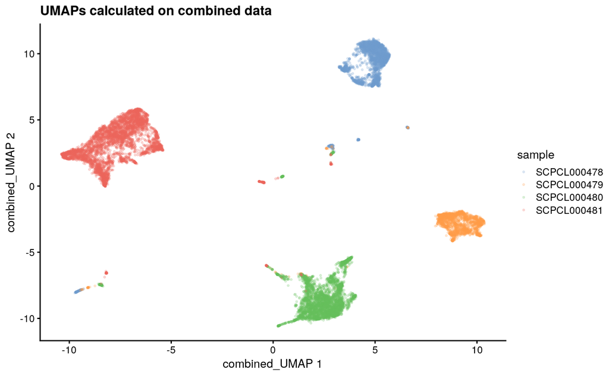

```r
# Here they were scaled together:
scater::plotReducedDim(combined_sce,
                       dimred = "combined_UMAP",
                       colour_by = "sample",
                       # Some styling to help us see the points:
                       point_size = 0.5,
                       point_alpha = 0.2) +
  ggplot2::ggtitle("UMAPs calculated on combined data")
```

```r
NA
NA
```

## Integration

To start, we’ll use `fastMNN` from the `batchelor` package:

```r
integrated_sce <- batchelor::fastMNN(combined_sce,
                                     # Specify the groups:
                                     batch = colData(combined_sce)$sample,
                                     # Optionally specify genes to use as the previously-ID'd
                                     # high variance genes
                                     subset.row = hvg_list
                                     )

integrated_sce
```

```
class: SingleCellExperiment
dim: 2000 14595
metadata(2): merge.info pca.info
assays(1): reconstructed
rownames(2000): ENSG00000157168 ENSG00000278996 ... ENSG00000197763 ENSG00000162244
rowData names(1): rotation
colnames(14595): SCPCL000478-CCTTTGGCACTACCCT SCPCL000478-GCAACCGGTCTTAGTG ...
  SCPCL000481-AAAGAACCACTTCAAG SCPCL000481-CAGCAGCTCGTGCATA
colData names(1): batch
reducedDimNames(1): corrected
mainExpName: NULL
altExpNames(0):
```

- The `reconstructed` assay are corrected expression values. Make sure to not use them for DE though!
- The `corrected` reduced dimensions are the PCs resulting from the corrected expression values. We can calculate UMAP embeddings from the PCs.

```r
# Specify the object's `reducedDim` name
integrated_sce <- scater::runUMAP(integrated_sce, dimred = "corrected")
integrated_sce
```

```
class: SingleCellExperiment
dim: 2000 14595
metadata(2): merge.info pca.info
assays(1): reconstructed
rownames(2000): ENSG00000157168 ENSG00000278996 ... ENSG00000197763 ENSG00000162244
rowData names(1): rotation
colnames(14595): SCPCL000478-CCTTTGGCACTACCCT SCPCL000478-GCAACCGGTCTTAGTG ...
  SCPCL000481-AAAGAACCACTTCAAG SCPCL000481-CAGCAGCTCGTGCATA
colData names(1): batch
reducedDimNames(2): corrected UMAP
mainExpName: NULL
altExpNames(0):
```

We can also/alternatively add this information into our `combined_sce` object to keep everything in one place:

```r
reducedDim(combined_sce, "fastmnn_PCA") <- reducedDim(integrated_sce, "corrected")
reducedDim(combined_sce, "fastmnn_UMAP") <- reducedDim(integrated_sce, "UMAP")
```

#### The before/after reveal

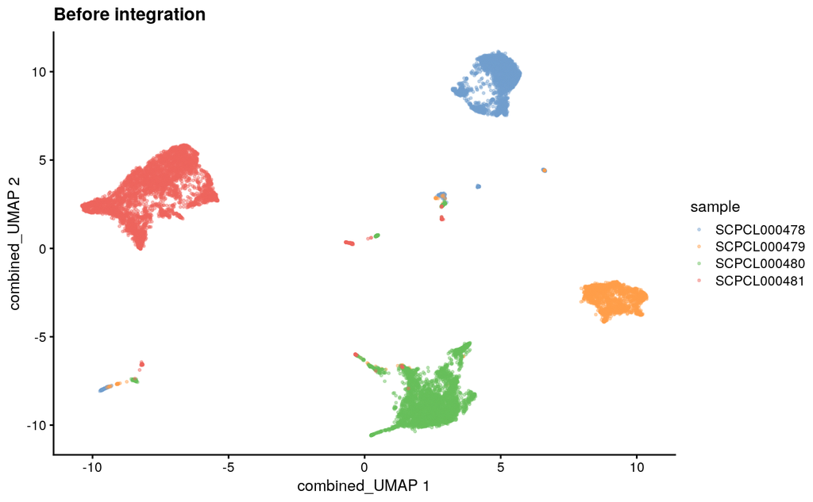

```r
# Before
scater::plotReducedDim(combined_sce,
                       dimred = "combined_UMAP",
                       colour_by = "sample",
                       # Some styling to help us see the points:
                       point_size = 0.5,
                       point_alpha = 0.4) +
  ggplot2::ggtitle("Before integration")
```

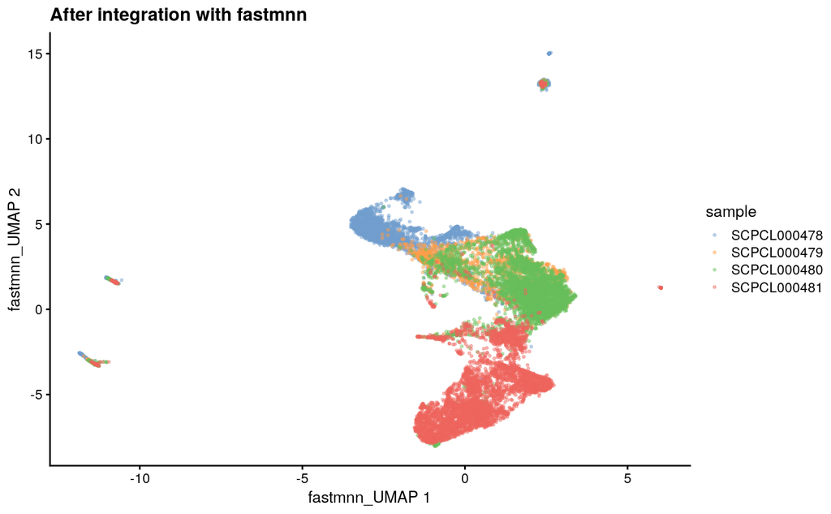

```r
# After
scater::plotReducedDim(combined_sce,
                       dimred = "fastmnn_UMAP",
                       colour_by = "sample",
                       # Some styling to help us see the points:
                       point_size = 0.5,
                       point_alpha = 0.4) +
  ggplot2::ggtitle("After integration with fastmnn")
```

## Integration, again!

There are more integration tools, like `harmony` for example! `harmony` differs from `fastMNN` (the entire algorithm-aside) in a few key ways:

- `harmony` allows you to specify additional covariates (technology, patient, diagnosis, etc.)
  - This requires slightly more setup - you’d need to pass in a data frame of covariates, not just a batch vector
- `harmony` does not calculate corrected expression values and only returns a matrix of corrected PCs
- a bonus key way is that `harmony` is on CRAN but `batchelor` is on bioconductor.

```r
# harmony can either start with PCs or with normalized (uncorrected) expression
# we already have PCs so let's just ask harmony to use those:
harmony_result <- harmony::HarmonyMatrix(
      # PCs
      data_mat  = reducedDim(combined_sce, "combined_PCA"),
      # batch information
      meta_data = colData(combined_sce)$sample,
      # don't run PCA since we gave PCs in `data_mat` argument
      do_pca = FALSE
    )
```

```
Harmony 1/10
Harmony 2/10
Harmony converged after 2 iterations
```

```r
# If we wanted to start with expression and have harmony calculate PCs for us:
#harmony::HarmonyMatrix(
#  data_mat  = logcounts(combined_sce),
#  meta_data = colData(combined_sce)$batch
#)

# The result is just a bunch of PCs!
harmony_result[1:5, 1:5]
```

```
                                  PC1         PC2        PC3       PC4        PC5
SCPCL000478-CCTTTGGCACTACCCT 4.671856  -1.3327787  -1.576646  2.759218  2.6398049
SCPCL000478-GCAACCGGTCTTAGTG 5.523577   0.3941267   4.143591  4.882758 -3.8564393
SCPCL000478-TCACTATCAAATCCCA 4.474783  -9.0403252  -9.363579 14.118100  0.8254695
SCPCL000478-TATATCCCACTCTCGT 4.273023 -10.4716570 -12.213370 16.512170  2.6119725
SCPCL000478-GCACTAACATTACGGT 5.736682  -1.4070253   4.156521  4.747673 -0.4201482
```

```r
# Let's store this directly into our `combined_sce` object, making sure to name it well!
reducedDim(combined_sce, "harmony_PCA") <- harmony_result

# Calculate UMAP with the right name for PCs:
# We do NOT want to overwrite the uncorrected UMAP! Make sure to name this differently with `name`
combined_sce <- scater::runUMAP(combined_sce, dimred = "harmony_PCA", name = "harmony_UMAP")
```

#### The before/after reveal, again!

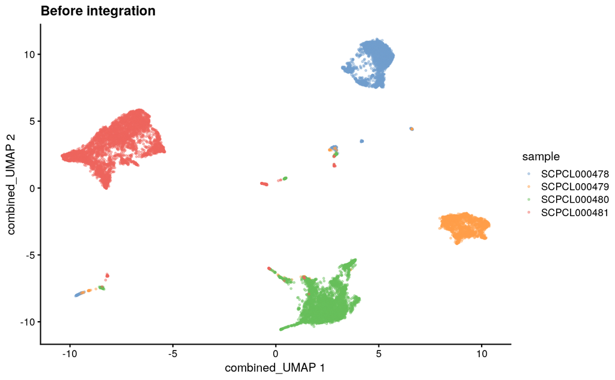

```r
# Before
scater::plotReducedDim(combined_sce,
                       dimred = "combined_UMAP",
                       colour_by = "sample",
                       # Some styling to help us see the points:
                       point_size = 0.5,
                       point_alpha = 0.4) +
  ggplot2::ggtitle("Before integration")
```

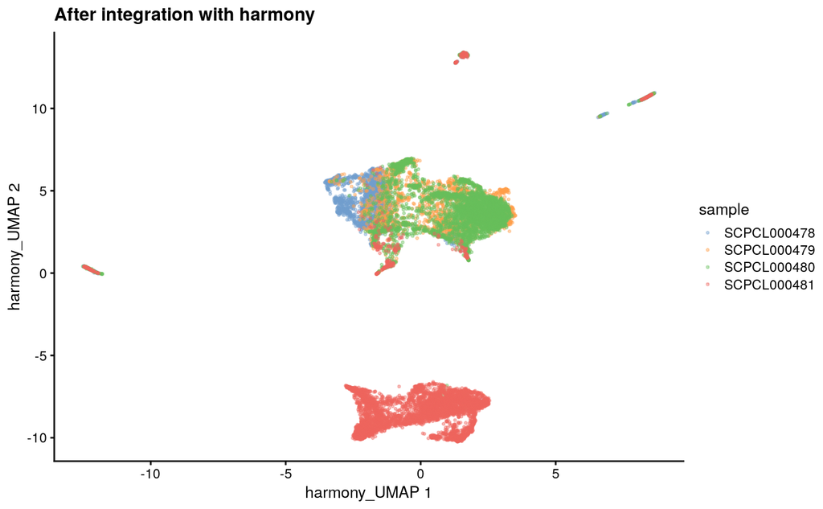

```r
# After
scater::plotReducedDim(combined_sce,
                       dimred = "harmony_UMAP",
                       colour_by = "sample",
                       # Some styling to help us see the points:
                       point_size = 0.5,
                       point_alpha = 0.4) +
  ggplot2::ggtitle("After integration with harmony")
```

## Comparing back to cell types

In an ideal world, we’d have cell types to refer to in UMAPs as well; well-integrated datasets should show more clustering of cell types and less clustering of batches. Surprise, it’s an ideal world!

Our SCE objects in fact contain this. Again, what are the cell types that have been identified?

```r
unique(combined_sce$celltype_broad)
```

```
 [1] NA                     "Vascular Endothelium" "Fibroblast"           "Tumor"                "Monocyte"
 [6] "Lymphocyte"           "Tumor_Myoblast"       "Tumor_Mesoderm"       "Tumor_Myocyte"        "Muscle"
```

Let’s compare before, fastmnn, and harmony UMAPs highlighting cell types (color) as well as library (shape).

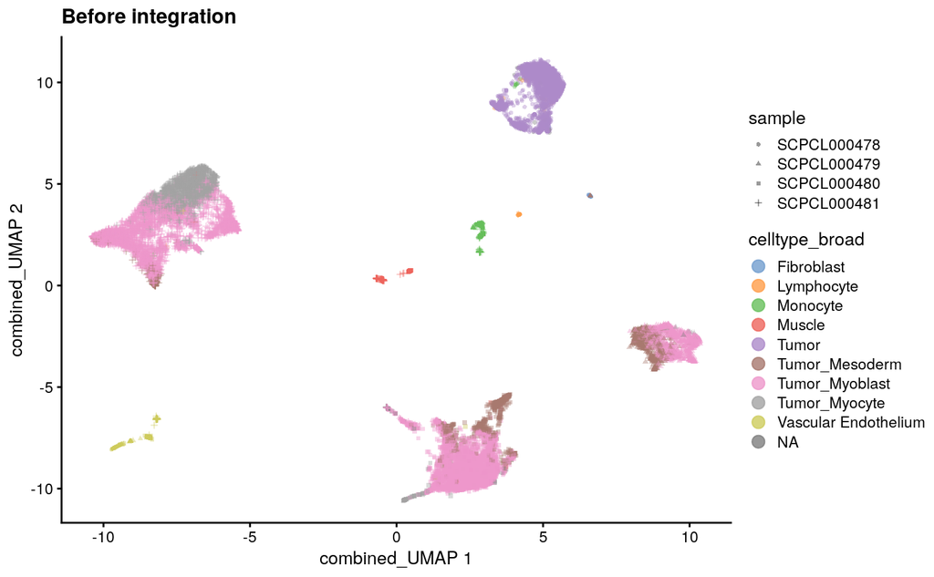

```r
# Before
scater::plotReducedDim(combined_sce,
                       dimred = "combined_UMAP",
                       colour_by = "celltype_broad",
                       shape_by = "sample",
                       # Some styling to help us see the points:
                       point_size = 0.8,
                       point_alpha = 0.4) +
  ggplot2::ggtitle("Before integration") +
  # And to help us see the colors in the legend:
  ggplot2::guides(colour = ggplot2::guide_legend(override.aes = list(size = 3,
                                                                     alpha = 0.8)))
```

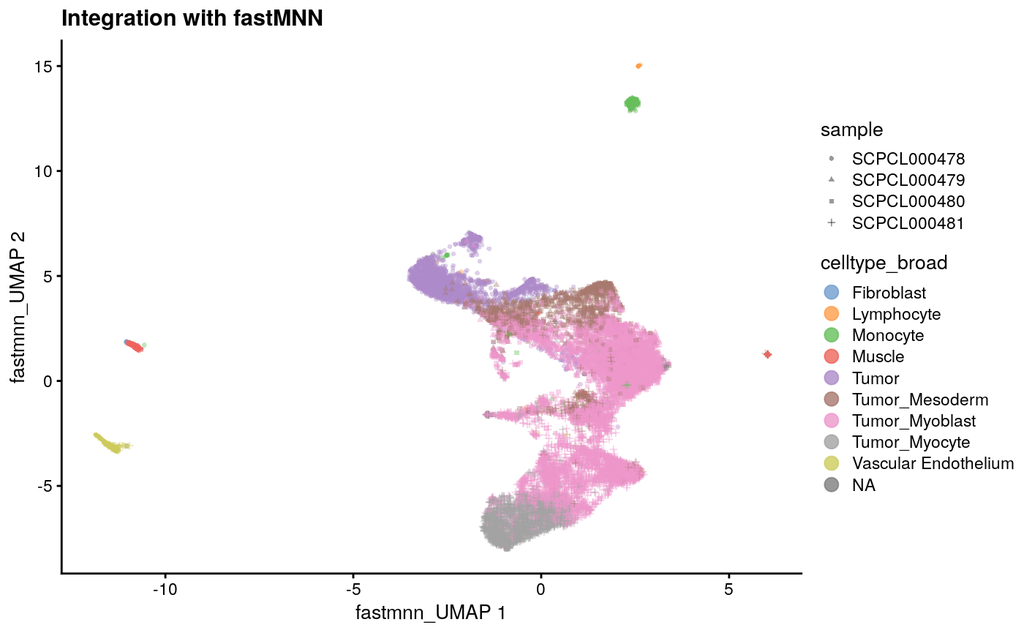

```r
# fastmnn
scater::plotReducedDim(combined_sce,
                       dimred = "fastmnn_UMAP",
                       colour_by = "celltype_broad",
                       shape_by = "sample",
                       # Some styling to help us see the points:
                       point_size = 0.8,
                       point_alpha = 0.4) +
  ggplot2::ggtitle("Integration with fastMNN") +
  # And to help us see the colors in the legend:
  ggplot2::guides(colour = ggplot2::guide_legend(override.aes = list(size = 3,
                                                                     alpha = 0.8)))
```

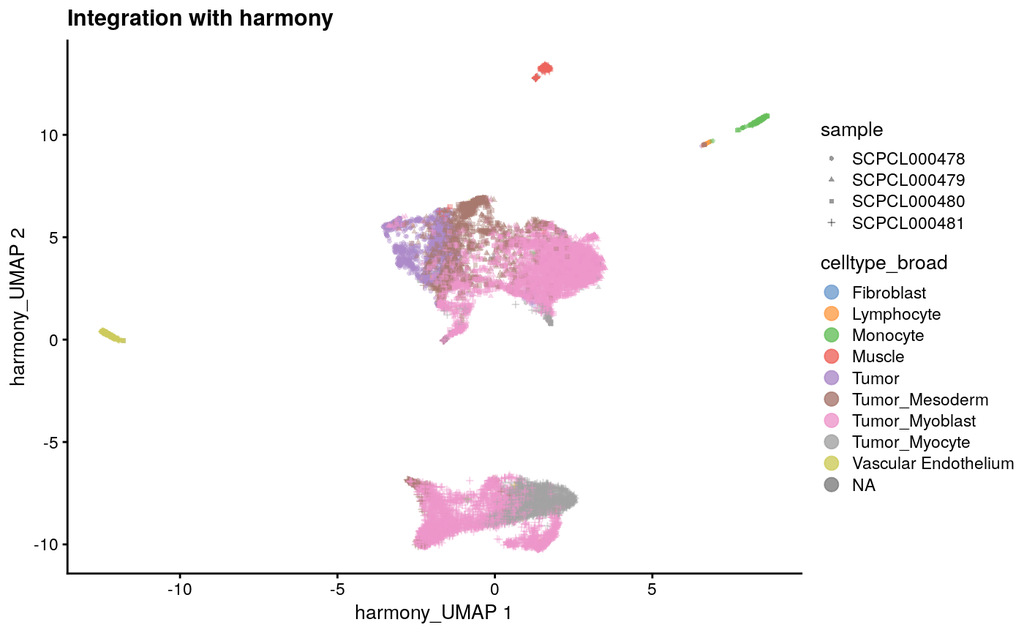

```r
# harmony
scater::plotReducedDim(combined_sce,
                       dimred = "harmony_UMAP",
                       colour_by = "celltype_broad",
                       shape_by = "sample",
                       # Some styling to help us see the points:
                       point_size = 0.8,
                       point_alpha = 0.4) +
  ggplot2::ggtitle("Integration with harmony") +
  # And to help us see the colors in the legend:
  ggplot2::guides(colour = ggplot2::guide_legend(override.aes = list(size = 3,
                                                                     alpha = 0.8)))
```